# CourseProject2

doyougnu

June 16, 2015

## Synopsis

This report analyzes data from the U.S. National Oceanic and Atmospheric Administration’s (NOAA) storm database. The goal of this report is twofold: 1. To determine which weather event, in the given database, is most harmful to human health. 2. Of the recorded weather events, which events are correlated to have the greatest amount of economic consequences. Economic consequences is used vaguely here, as one could analyze the oppurtunity cost of lost lives or crops, or one could merely ignore consequences of a lost. Given the dataset this author chose to focus on economic damage, in place of economic consequences. It was found that the tornado is the most costly weather event in terms of human health. The most economically damaging weather event was found the be a flood. In sum, both of these results imply that the dataset should be analyzed in terms of geographic data, because floods and tornadoes are location specific.

## Data Preprocessing

The following environment was used to process, and analyze the date:

```r
Sys.info()
```

```
##                                                                                            sysname
##                                                                                           "Darwin"
##                                                                                            release
##                                                                                           "14.3.0"
##                                                                                            version
## "Darwin Kernel Version 14.3.0: Mon Mar 23 11:59:05 PDT 2015; root:xnu-2782.20.48~5/RELEASE_X86_64"
##                                                                                           nodename
##                                                                       "Jeffreys-MacBook-Pro.local"
##                                                                                            machine
##                                                                                           "x86_64"
##                                                                                              login
##                                                                                         "DrRuckus"
##                                                                                               user
##                                                                                         "DrRuckus"
##                                                                                     effective_user
##                                                                                         "DrRuckus"
```

```r
R.Version()
```

```
## $platform
## [1] "x86_64-apple-darwin13.4.0"
##
## $arch
## [1] "x86_64"
##
## $os
## [1] "darwin13.4.0"
##
## $system
## [1] "x86_64, darwin13.4.0"
##
## $status
## [1] ""
##
## $major
## [1] "3"
##
## $minor
## [1] "1.3"
##
## $year
## [1] "2015"
##
## $month
## [1] "03"
##
## $day
## [1] "09"
##
## $`svn rev`
## [1] "67962"
##
## $language
## [1] "R"
##
## $version.string
## [1] "R version 3.1.3 (2015-03-09)"
##
## $nickname
## [1] "Smooth Sidewalk"
```

The data is available [here](https://d396qusza40orc.cloudfront.net/repdata%2Fdata%2FStormData.csv.bz2), and comes in bzip2 form. To load this into R we perform the following operations:

```r
download.file("https://d396qusza40orc.cloudfront.net/repdata%2Fdata%2FStormData.csv.bz2", "FStormData.csv.bz2", method = "curl")
df.raw <- read.csv(bzfile("FStormData.csv"), header = TRUE, sep = ",")
```

Now lets have a look at the first few lines to see how R is interpreting the data, and the subset the dataframe:

```r
str(df.raw)
```

```
## 'data.frame':    902297 obs. of  37 variables:
##  $ STATE__   : num  1 1 1 1 1 1 1 1 1 1 ...
##  $ BGN_DATE  : Factor w/ 16335 levels "1/1/1966 0:00:00",..: 6523 6523 4242 11116 2224 2224 2260 383 3980 3980 ...
##  $ BGN_TIME  : Factor w/ 3608 levels "00:00:00 AM",..: 272 287 2705 1683 2584 3186 242 1683 3186 3186 ...
##  $ TIME_ZONE : Factor w/ 22 levels "ADT","AKS","AST",..: 7 7 7 7 7 7 7 7 7 7 ...
##  $ COUNTY    : num  97 3 57 89 43 77 9 123 125 57 ...
##  $ COUNTYNAME: Factor w/ 29601 levels "","5NM E OF MACKINAC BRIDGE TO PRESQUE ISLE LT MI",..: 13513 1873 4598 10592 4372 10094 1973 23873 24418 4598 ...
##  $ STATE     : Factor w/ 72 levels "AK","AL","AM",..: 2 2 2 2 2 2 2 2 2 2 ...
##  $ EVTYPE    : Factor w/ 985 levels "   HIGH SURF ADVISORY",..: 834 834 834 834 834 834 834 834 834 834 ...
##  $ BGN_RANGE : num  0 0 0 0 0 0 0 0 0 0 ...
##  $ BGN_AZI   : Factor w/ 35 levels "","  N"," NW",..: 1 1 1 1 1 1 1 1 1 1 ...
##  $ BGN_LOCATI: Factor w/ 54429 levels ""," Christiansburg",..: 1 1 1 1 1 1 1 1 1 1 ...
##  $ END_DATE  : Factor w/ 6663 levels "","1/1/1993 0:00:00",..: 1 1 1 1 1 1 1 1 1 1 ...
##  $ END_TIME  : Factor w/ 3647 levels ""," 0900CST",..: 1 1 1 1 1 1 1 1 1 1 ...
##  $ COUNTY_END: num  0 0 0 0 0 0 0 0 0 0 ...
```

[output cut: 23 more lines]

```r
df <- subset(df.raw, select = c("PROPDMGEXP", "PROPDMG", "CROPDMGEXP", "CROPDMG",
                            "BGN_DATE", "EVTYPE", "FATALITIES", "INJURIES"))
```

This analysis is focused on the EVTYPE (Event Type) variable, as such it must be cleaned in order to be useful. First of all we cannot have “THUNDERSTORM” and “TSTM” mean the same thing in our analysis. Also, white spaces and special characters must be removed, and any other “EVTYPE” that does not make sense for this analysis:

```r
#remove special characters
library(dplyr)
df$EVTYPE <- gsub("[[:punct:]]", "", df$EVTYPE)
df$EVTYPE <- tolower(df$EVTYPE)

#remove summaries, monthly/weekly summaries
patternsToRemove <- c("monthly", "?")
greplString <- paste(patternsToRemove, collapse = "|")
df <- df[(grepl(greplString, df$EVTYPE)),]

#remove everything that has summary in it
df <- df[(!grepl("summary", df$EVTYPE)),]

#turn TSTM into Thunderstorm
tstorm <- c("thunderstorms", "thunderstormw", "tstm", "thunderstorminds", "thunderstorminds", "thunderstrom", "thundertorm", "thundertsorm", "thundestorm", "thunerstorm", "thunderstorminds")
tstormGsub <- paste(tstorm, collapse = "|")
df$EVTYPE <- gsub(tstormGsub, "thunderstorm", df$EVTYPE)
df$EVTYPE <- factor(df$EVTYPE)
```

Now clean the economic data by converting the PROPDMGEXP and CROPDMGEXP variables to scientific notation, concatenating with PROPDMG/CROPDMG, and generating the final DMG variables

```r
fixDMG <- function(x){
#function takes a list, loops through the list converting values to scientific
#notation, converts list class to character to anticipate future paste call
    x <- toupper(x)
    x <- gsub("[[:punct:]]", "", x)
    x <- lapply(toupper(x), function(x)
        ifelse(x == "K", "000",
               ifelse(x =="M", "000000",
                      ifelse(x == "B", "000000000", x))))

    x <- as.character(unlist(x))
    x
}
df$CROPDMGEXP <- fixDMG(df$CROPDMGEXP)
df$PROPDMGEXP <- fixDMG(df$PROPDMGEXP)

#convert and concatenate damage variables
df$PROPDMG <- as.character(df$PROPDMG)
df$CROPDMG <- as.character(df$CROPDMG)
df$propertyDamage <- as.numeric(paste(df$PROPDMG, df$PROPDMGEXP, sep = ""))
df$cropDamage <- as.numeric(paste(df$CROPDMG, df$CROPDMGEXP, sep = ""))
```

## Model Definition

To asses the impact of Climate Events to human health and the Economy I will be using a simple sum model. Thus INJURIES and FATALITIES will be summed across the all time periods in the data frame. The same type of model will be used to analyze the economic damage as well. I prefer to use the [dplyr](http://cran.rstudio.com/web/packages/dplyr/vignettes/introduction.html) package for operations like this:

```r
#aggregate for human impact analysis
library(dplyr)

populationHealth <- df %>%
                       group_by(EVTYPE) %>%
                            summarise(humanInjuries =
                                        sum(INJURIES, na.rm = TRUE),
                                      humanDeaths =
                                        sum(FATALITIES, na.rm = TRUE),
                                      total =
                                        sum(INJURIES,
                                            FATALITIES, na.rm = TRUE)) %>%
                                arrange(desc(total))

#aggregate for economic impact
econHealth <- df %>%
                group_by(EVTYPE) %>%
                    summarise(propertyImpact =
                                  sum(propertyDamage, na.rm = TRUE),
                              cropImpact =
                                  sum(cropDamage, na.rm = TRUE),
                              total =
                                sum(cropDamage,
                                    propertyDamage, na.rm = TRUE)) %>%
                        arrange(desc(total))
```

## Results

```r
populationHealth[1:15,]
```

```
## Source: local data frame [15 x 4]
##
##                EVTYPE humanInjuries humanDeaths total
## 1             tornado         91346        5633 96979
## 2   thunderstorm wind          8445         637  9082
## 3      excessive heat          6525        1903  8428
## 4               flood          6789         470  7259
## 5           lightning          5230         817  6047
## 6                heat          2100         937  3037
## 7         flash flood          1777         978  2755
## 8           ice storm          1975          89  2064
## 9        winter storm          1321         206  1527
## 10          high wind          1137         248  1385
## 11               hail          1361          15  1376
## 12   hurricanetyphoon          1275          64  1339
## 13         heavy snow          1021         127  1148
## 14           wildfire           911          75   986
## 15 thunderstorm winds           909          65   974
```

```r
econHealth[1:15,]
```

```
## Source: local data frame [15 x 4]
##
##                EVTYPE propertyImpact cropImpact        total
## 1               flood   139757262679 5254498448 145011761127
## 2             tornado    44505453615  391298870  44896752485
## 3    hurricanetyphoon    21484971367  938202661  22423174029
## 4                hail    12791104922 2628329396  15419434319
## 5         flash flood    13493723891 1368908101  14862631992
## 6           hurricane     8121851548 2183600558  10305452106
## 7         river flood     5106745013 5029459000  10136204013
## 8             drought      382056664 9499449974   9881506638
## 9   thunderstorm wind     7212320312  839989348   8052309660
## 10          ice storm     2996592925 5006660019   8003252944
## 11       winter storm     6313730812   20954006   6334684818
## 12    storm surgetide     4626138015     850000   4626988015
## 13          high wind     2587418049  463866969   3051285018
## 14           wildfire     2194384962  225956186   2420341149
## 15 thunderstorm winds     1703069845  186306934   1889376779
```

I would expect earthquakes to be at the top of the list because given the model the event type which maximizes injuries and deaths will also maximize the “total impact”. Likewise for the economic damage, however earthquakes are not defined as a “weather event” in this dataset.

Here are some plots to describe the most costly weather events in terms of economic and human impact:

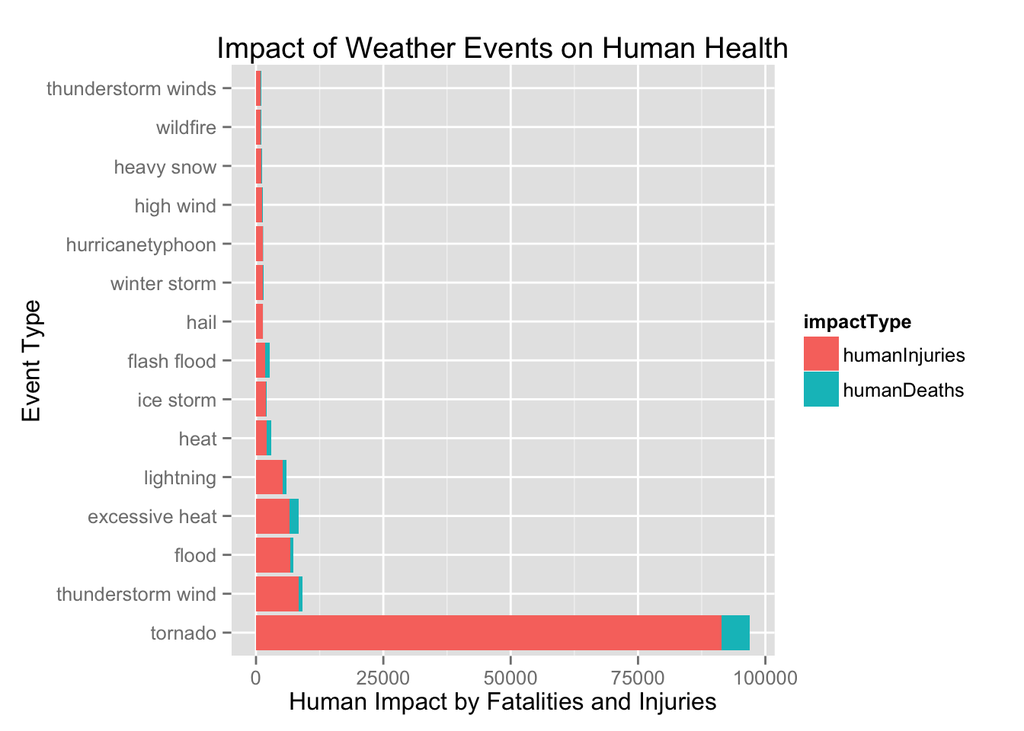

```r
#load ggplot2
library(ggplot2)

#subset data for plots
populationHealth.sub <- populationHealth[1:15, 1:3]
econHealth.sub <- econHealth[1:15, 1:3]

#melt data to long tidy form
library(tidyr)
populationHealth.sub.tidy <- populationHealth.sub %>%
    gather(impactType, impact, 2:3) %>%
        arrange(impactType, desc(impact))

econHealth.sub.tidy <- econHealth.sub %>%
        gather(impactType, impact, 2:3) %>%
            arrange(impactType, desc(impact))

#plots
ggplot(populationHealth.sub.tidy, aes(x = factor(EVTYPE, levels = EVTYPE),
                                      y = impact,
                                      fill = impactType)) +
    geom_bar(stat = "identity") +
    coord_flip() +
    ggtitle("Impact of Weather Events on Human Health") +
    labs(y = "Human Impact by Fatalities and Injuries", x = "Event Type")
```

[figure not shown]

```r
ggplot(econHealth.sub.tidy, aes(x = factor(EVTYPE, levels = EVTYPE),
                                y = impact/100000000,
                                fill = impactType)) +
    geom_bar(stat = "identity") +
    coord_flip() +
    ggtitle("Economic Impact by Weather Event") +
    labs(y = "Economic Impact in Billions of Dollars", x = "Event Type")
```

Taking the plots in order: The most costly weather event in terms of human wellbeing (defined as the sum of injuries and deaths) is the occurance of a tornado. Tornado’s dominate the dataset by an order of magnitude in injury count. As this model treats an injury equal to a death this assymetry causes the model to conclude the tornado as the most costly weather event to human wellbeing. In the future this model could be revised, or merely reduced to a peerly economic analysis; while some might find equating a life to a price value the oppurtunity cost of a death is substantial and of economic importance, so that analysis may have some merit.

Turning to the economic analysis, the most costly weather event is a flood. For similary reasons to the tornado, the flood dominates the model by maximizing the property impact variable. The results of flood and tornados dominating the model leads me to think that the dataset may be biased towards the southwest. I would certainly expect it to be biased towards population centers - as there is no health nor economic impact without people. Future analyses may try to analyze this dataset in relation to geographic or socioeconomic data; or for that matter reduce to the cropImpact veriable to a property Impact metric, as a crop is a form of property.